# Final Project

Final Project SENA İSBİLİR 2026-07-27

SUMMARY

In this assignment, correlations of abortion with wealth, highest level of education participants attended, age, and region were evaluated.Based on the analysis, the following results were obtained:

1- Between abortion by abortives and a specialist, the participant preferred more the abortion by a specialist **(g1 chart)**. 2- Kotayk and Lori regions presented the highest total abortion counts **(t1 table)**. 3- Kotayk, Armavir, Gegharkunik, and Shirak regions were recorded as the wealthiest regions; however, a direct correlation between wealth and total abortion was not observed even though wealth had an effect on the abortion count **(t2 table)**. 4- The highest education level was recorded in Gegharkunik while participants with secondary and secondary special education level as the highest education level attended showed to have higher wealth than others **(g2 chart)**. 5- Abortions were conducted mostly by **Secondary** and **Secondary special** group among other highest education level categories regardless of method of abortion **(g3 and g4 charts)**. 6- **Shirak** region was observed as the region containing the youngest (25) and oldest (>48) abortion age records. The age group with the highest abortion count was 40-50. Lastly, regions of **Kotayk**, **Lori**, and **Gegharkunik** had higher abundance among other regions regardless of age group **(g5 chart)**.

INTRODUCTION Data: 2015 Armenia Demographic and Health Survey by DHS In this project, topic of abortion in 2015 of Armenia was evaluated.For this purpose, relation between wealth, region, education and abortion was examined.

#**1-Loading data and reading in the .DTA file**

**2-Preparation of Data for Plotting**

```
## # A tibble: 6,116 × 7
##    c_age region  wealth t_abort_by_specialist abortion_by_abortives t_abortions
##    <dbl> <fct>    <dbl>                 <dbl>                 <dbl>       <dbl>
##  1    32 yerevan 115855                     0                     0           0
##  2    27 yerevan 106535                     0                     0           0
##  3    40 yerevan 130720                     0                     1           1
##  4    27 yerevan  28540                     0                     0           0
##  5    27 yerevan 114198                     0                     0           0
##  6    36 yerevan   6062                     0                     0           0
##  7    29 yerevan 126848                     0                     0           0
##  8    25 yerevan 126848                     0                     0           0
##  9    29 yerevan 118796                     0                     0           0
## 10    38 yerevan 106555                     0                     0           0
## # ℹ 6,106 more rows
## # ℹ 1 more variable: highest_edu <fct>
```

**3-Plotting**

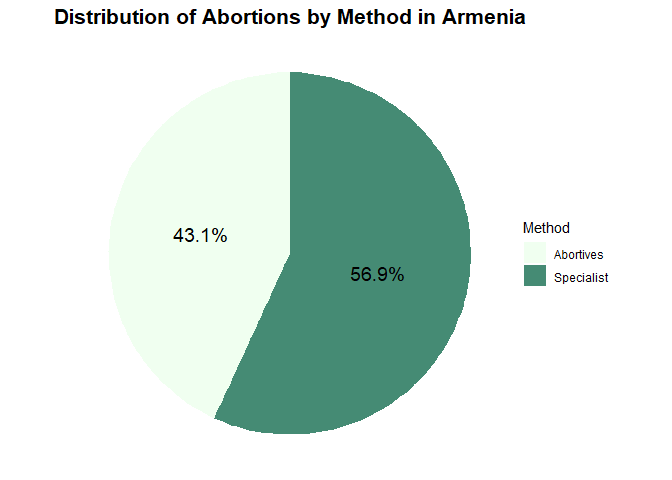

According to the pie chart (g1), **abortion performed by a specialist** was the most preferred method, accounting for 56.9% of abortions in 2015.

| Region | Wealth | Total Abortions |
| --- | --- | --- |
| Kotayk | -71,418 | 11 |
| Lori | 4,881 | 10 |
| Gegharkunik | -36,237 | 8 |
| Lori | -203,907 | 8 |
| Shirak | 149,699 | 7 |
| Lori | 59,232 | 7 |
| Gegharkunik | 11,927 | 7 |
| Gegharkunik | 160,055 | 6 |
| Kotayk | 132,336 | 6 |
| Yerevan | 75,234 | 6 |
| Armavir | 37,785 | 6 |
| Gegharkunik | 3,095 | 6 |
| Ararat | -123,342 | 6 |
| Shirak | 57,978 | 5 |
| Gegharkunik | 36,347 | 5 |
| Gegharkunik | 35,339 | 5 |
| Gegharkunik | 28,454 | 5 |
| Armavir | -28,499 | 5 |
| Lori | -158,513 | 5 |
| Gegharkunik | -337,687 | 5 |
| Kotayk | 254,624 | 4 |
| Kotayk | 136,670 | 4 |
| Ararat | 99,158 | 4 |
| Gegharkunik | 84,789 | 4 |
| Gegharkunik | 68,865 | 4 |
| Gegharkunik | 60,971 | 4 |
| Shirak | 57,519 | 4 |
| Gegharkunik | 50,575 | 4 |
| Shirak | 43,231 | 4 |
| Syunik | 40,946 | 4 |
| Gegharkunik | 25,696 | 4 |
| Ararat | 20,654 | 4 |
| Armavir | 20,408 | 4 |
| Ararat | 16,081 | 4 |
| Armavir | -240,728 | 4 |
| Gegharkunik | 176,860 | 3 |
| Shirak | 133,850 | 3 |
| Gegharkunik | 121,922 | 3 |
| Kotayk | 93,638 | 3 |
| Gegharkunik | 90,464 | 3 |
| Ararat | 69,793 | 3 |
| Ararat | 37,352 | 3 |
| Kotayk | 25,222 | 3 |
| Armavir | 19,962 | 3 |
| Armavir | -6,559 | 3 |
| Vayots Dzor | -126,199 | 3 |
| Gegharkunik | -160,025 | 3 |
| Armavir | 180,370 | 2 |
| Shirak | 93,443 | 2 |
| Yerevan | 29,784 | 2 |
| Ararat | 28,818 | 2 |
| Ararat | 21,768 | 2 |
| Armavir | -4,545 | 2 |
| Shirak | -16,114 | 2 |
| Tavush | -26,963 | 2 |
| Aragatsotn | -53,851 | 2 |
| Ararat | -78,868 | 2 |
| Armavir | -97,474 | 2 |
| Shirak | -97,859 | 2 |
| Gegharkunik | -449,733 | 2 |
| Gegharkunik | -725,896 | 2 |
| Gegharkunik | -831,714 | 2 |

Based on the table **(t1)**, **Kotayk** region followed by **Lori** had the highest total abortion count. However, Lori region showed the top 5 highest total abortion count regardless of wealth value.So, this dataset presents that there are other factors affecting the total abortion count.

| region | wealth | t_abortions |
| --- | --- | --- |
| Kotayk | 254624 | 4 |
| Armavir | 180370 | 2 |
| Gegharkunik | 176860 | 3 |
| Gegharkunik | 160055 | 6 |
| Shirak | 149699 | 7 |
| Kotayk | 136670 | 4 |
| Shirak | 133850 | 3 |
| Kotayk | 132336 | 6 |
| Gegharkunik | 121922 | 3 |
| Ararat | 99158 | 4 |

[output cut: 52 more lines]

The wealthiest regions were **Kotayk, Armavir, Gegharkunik, and Shirak**. Wealth in these regions showed variation. However, with the data presented in this table **t2**, it can be concluded that effect of wealth on total abortion showed variation based on region. Still, there is no direct correlation among the variables. So, based on the results it can be stated that there are other factors rather than wealth and region affecting the total abortion count in 2015 in Armenia.

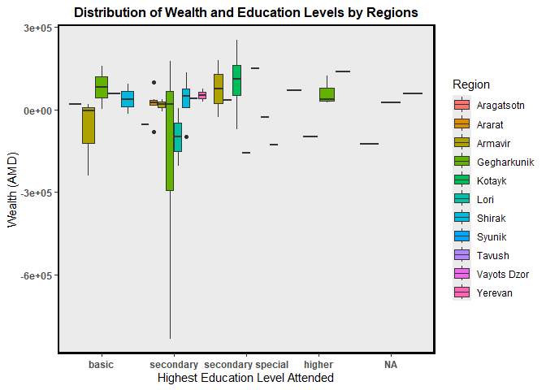

According to **g2 chart** here, participants from Kotayk and Armavir regions whose the highest level of education attended was secondary special were the wealthiest among others.On the other hand, participants from Gegharkunik region has the higher education level attended but they were not wealthiest indicating the wealth also was independent of level of education.

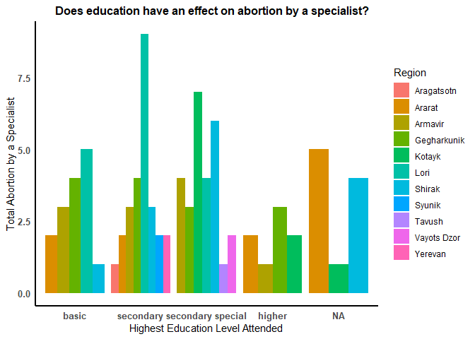

The chart **(g3)** presented that highest education level attended that preferred the most abortion by a specialist were secondary and secondary special group accounted for the majority of the participants’ highest education level attended. But, there was no direct correlation between highest education level attended and abortion by a specialist.

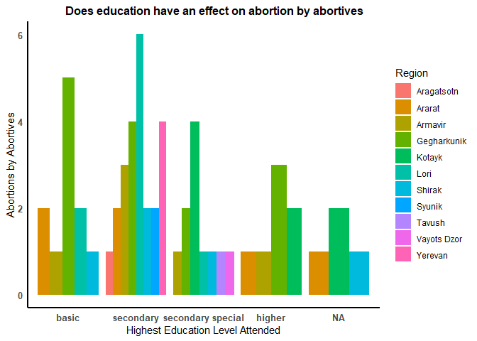

Similar results with **g3** obtained in **g4** (the chart above here). This may indicate that there was no significant difference in method of abortion based on highest level of education attended and region.

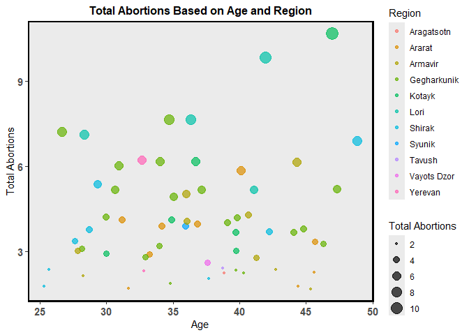

The bubble chart **(g5)** displays that participants whose age above 40 had the highest total abortion count. Also, independent of age, regions of **Kotayk**, **Lori**, and **Gegharkunik** presented more prominent total abortion count. Lastly, both the youngest (25) and oldest (>48) abortion ages were recorded in **Shirak** region.